# Final Exam

Reese Quillian

2022-12-09

```r
# load libraries
library(forecast)
library(mtsdi)
library(MTS)
```

```r
library(ggplot2)
library(ggfortify)
library(tseries)
library(ggpubr)
library(tidyverse)
library(ggResidpanel)
library(psych)
library(GGally)
library(devtools)
library(here)
library(dplyr)
library(MASS)
library(lindia)
# set up
sourcedir <- "C:/Users/Student/OneDrive - University of Virginia/Documents/SYS4021/In Class"
datadir <- "C:/Users/Student/OneDrive - University of Virginia/Documents/SYS4021/In Class/Data"

setwd(sourcedir)

source("PCAplots.R")
source("FactorPlots.R")
source("pc.glm.R")
source("ROC.R")
source("TestSet.R")

# load data
```

# Part 1 Linear Regression

```r
app <- read.table("app.csv", sep = ",", header = T)
```

Question 1

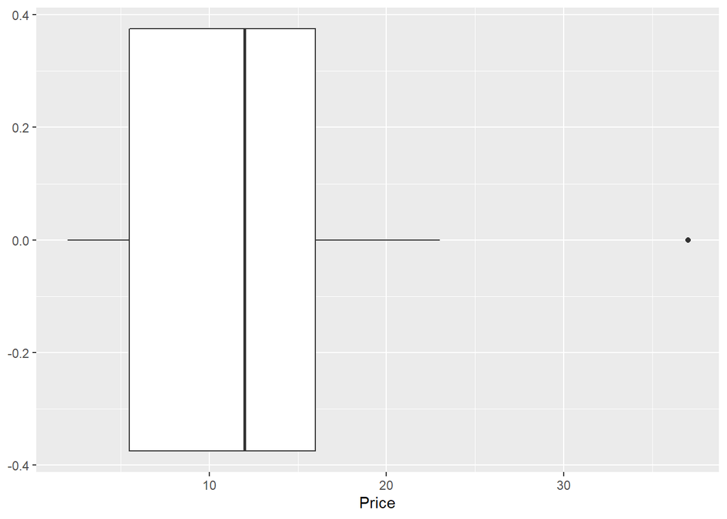

```r
ggplot(data=app, aes(x=Price)) + geom_boxplot()
```

```r
# 1 outlier
boxplot.stats(app$Price)
```

```
## $stats
## [1]  2.0  5.5 12.0 16.0 23.0
##
## $n
## [1] 31
##
## $conf
## [1]  9.020348 14.979652
##
## $out
## [1] 37
```

Question 2 Use a scatter plot matrix or individual scatter plots and list the variable in the data set that has the strongest linear relationship to Price. A. Platform B. Develop C. X5Star D. CompSites **E. Date** F. Advert G. Users

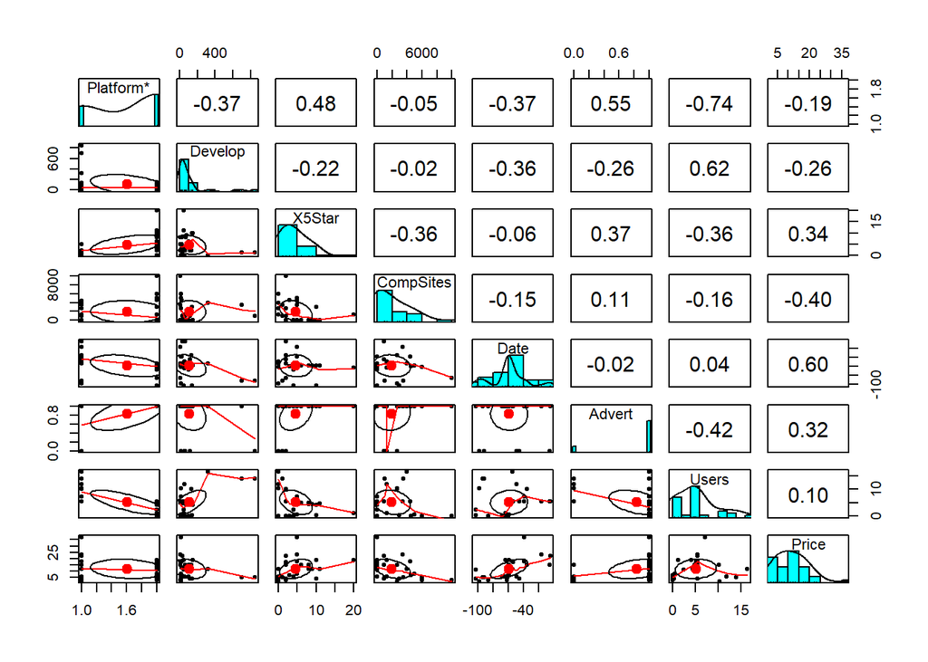

```r
pairs.panels(app[,c("Platform","Develop", "X5Star", "CompSites", "Date","Advert","Users","Price")])
```

Question 3 Which of the following is a main effects + interactions model using just Platform and Users as predictors of Price if the base case for Platform is Android?

```r
table(app$Platform)
```

```
##
##  Droid iPhone
##     12     19
```

Question 4 Build a main effects + interaction model using only Users and Platform as predictors of Price

```r
app.lm<-lm(Price~(Users+Platform)^2,data=app)
summary(app.lm)
```

```
##
## Call:
## lm(formula = Price ~ (Users + Platform)^2, data = app)
##
## Residuals:
##     Min      1Q  Median      3Q     Max
## -14.381  -2.796  -0.381   1.549  20.728
##
## Coefficients:
##                      Estimate Std. Error t value Pr(>|t|)
## (Intercept)           25.2044     4.7402   5.317  1.3e-05 ***
## Users                 -1.2406     0.4703  -2.638 0.013671 *
## PlatformiPhone       -19.1376     5.2140  -3.670 0.001051 **
## Users:PlatformiPhone   3.1297     0.7989   3.917 0.000551 ***
## ---
## Signif. codes:  0 '***' 0.001 '**' 0.01 '*' 0.05 '.' 0.1 ' ' 1
##
## Residual standard error: 6.331 on 27 degrees of freedom
## Multiple R-squared:  0.3868, Adjusted R-squared:  0.3187
## F-statistic: 5.678 on 3 and 27 DF,  p-value: 0.003781
```

```r
AIC(app.lm)
```

```
## [1] 208.1062
```

Question 5 Build a main effects model to predict Price using all predictor variables.

```r
app.lm.full <- lm(Price~Platform+Develop+X5Star+CompSites+Date+Advert+Users,data=app)
summary(app.lm.full)
```

```
##
## Call:
## lm(formula = Price ~ Platform + Develop + X5Star + CompSites +
##     Date + Advert + Users, data = app)
##
## Residuals:
##     Min      1Q  Median      3Q     Max
## -5.2332 -2.8447 -0.7443  1.9539 13.2732
##
## Coefficients:
##                  Estimate Std. Error t value Pr(>|t|)
## (Intercept)    12.8813465  3.9044154   3.299  0.00314 **
## PlatformiPhone -8.0088021  3.6648490  -2.185  0.03931 *
## Develop        -0.0085754  0.0064504  -1.329  0.19674
## X5Star          0.4961003  0.2434916   2.037  0.05327 .
## CompSites      -0.0009987  0.0004255  -2.347  0.02790 *
## Date            0.0938387  0.0489606   1.917  0.06779 .
## Advert         10.8707634  2.9446854   3.692  0.00121 **
## Users           0.1781347  0.3591642   0.496  0.62462
## ---
## Signif. codes:  0 '***' 0.001 '**' 0.01 '*' 0.05 '.' 0.1 ' ' 1
##
## Residual standard error: 4.523 on 23 degrees of freedom
## Multiple R-squared:  0.7334, Adjusted R-squared:  0.6523
## F-statistic: 9.039 on 7 and 23 DF,  p-value: 2.371e-05
```

```r
AIC(app.lm.full)
```

```
## [1] 190.2863
```

Question 6 Between the models in Questions 4 and 5, which do you choose?

- main effects bc lower AIC and higher R-squared

Question 7

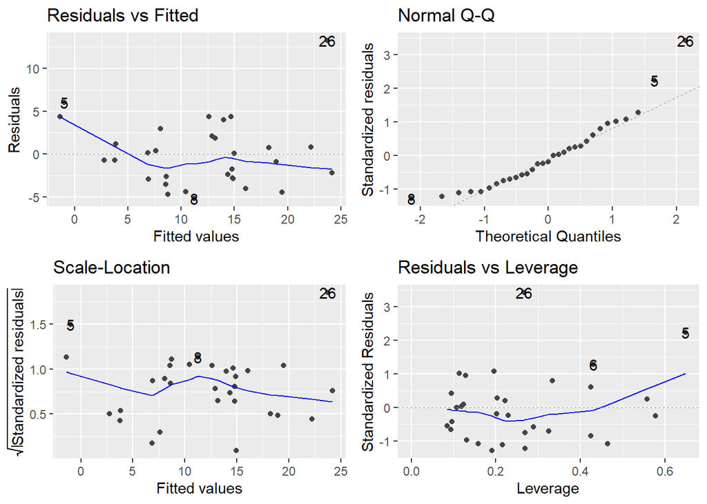

```r
autoplot(app.lm.full)
```

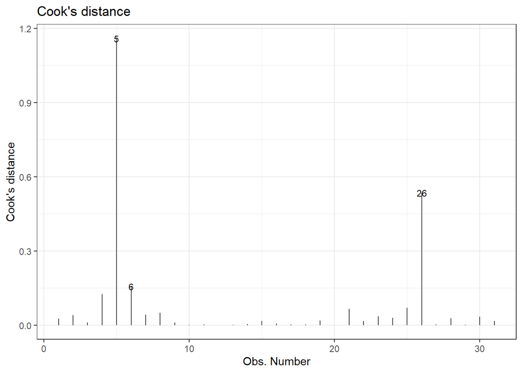

```r
autoplot(app.lm.full, which=4, ncol = 1, label.size = 3) + theme_bw()
```

Question 8

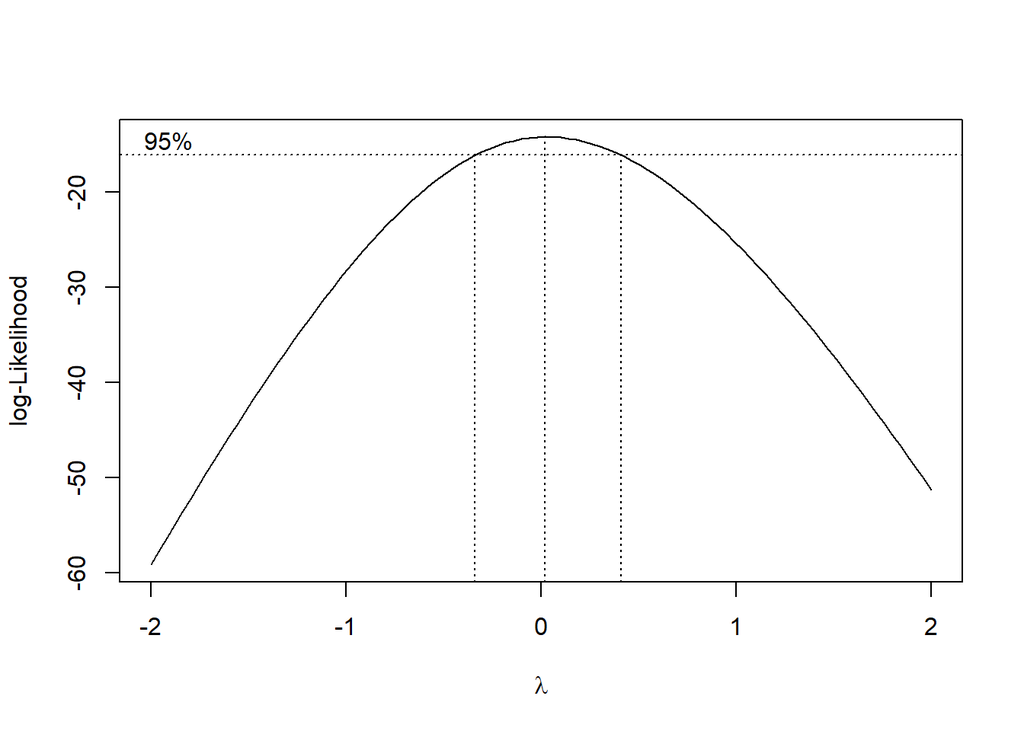

```r
boxcox(app.lm.full) #box-cox plot
```

Question 9 Which variables in this dataset can you not include in principal components analysis? - qualitative

```r
str(app)
```

```
## 'data.frame':    31 obs. of  8 variables:
##  $ Price    : int  4 11 2 5 5 3 6 6 19 3 ...
##  $ Platform : chr  "iPhone" "iPhone" "Droid" "Droid" ...
##  $ Develop  : int  138 52 16 695 845 7 106 57 51 22 ...
##  $ X5Star   : int  10 4 0 1 1 2 4 4 20 0 ...
##  $ CompSites: int  3000 0 2640 3500 1000 10000 0 0 1300 6000 ...
##  $ Date     : int  -103 -103 -98 -93 -92 -86 -68 -64 -63 -62 ...
##  $ Advert   : int  1 1 0 1 0 1 1 1 1 1 ...
##  $ Users    : num  0.3 2.5 10.3 14 14 0 0 0 1.2 0 ...
```

```r
# platform
```

Question 10 Using all of the variables that can be used for PCA, perform PCA with the correlation matrix. Which two variables have the highest absolute loading in the first PC?

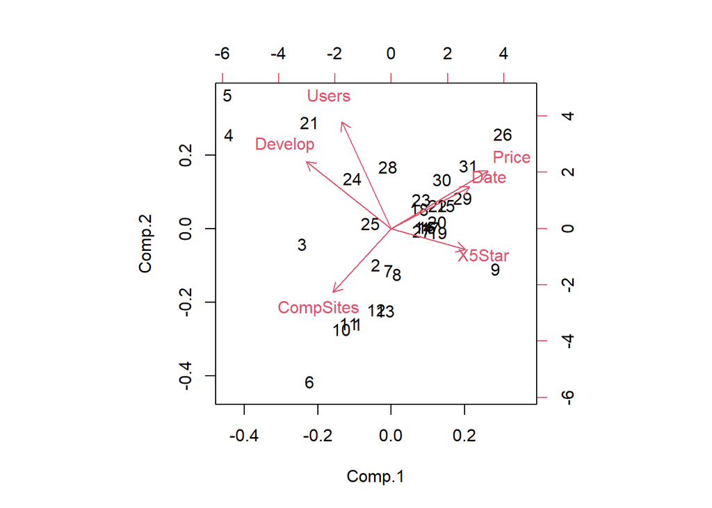

```r
app.pca <- princomp(app[,c("Price", "Develop", "X5Star", "CompSites", "Date","Users")], cor = T)
biplot(app.pca)
```

```r
loadplot <- loadingsplot(app.pca)
loadplot$loadings
```

```
##     Variable     Comp.1     Comp.2      Comp.3      Comp.4      Comp.5
## 1:     Price  0.5240135  0.3619447  0.08677298 0.402975424  0.42034140
## 2:   Develop -0.4615245  0.4204802 -0.27653569 0.309755464 -0.51641899
## 3:    X5Star  0.4008824 -0.1301814 -0.61963123 0.464424500 -0.19726967
## 4: CompSites -0.3161436 -0.3992747  0.46108719 0.717568966  0.06584716
## 5:      Date  0.4234878  0.2607676  0.56173668 0.001828718 -0.62898610
## 6:     Users -0.2690904  0.6691974  0.06249879 0.105184026  0.34314698
##         Comp.6
## 1:  0.49779541
## 2:  0.41362126
## 3: -0.42871649
## 4: -0.09375733
## 5: -0.20367476
## 6: -0.58910569
```

# Part 2: GLM

```r
heart <- read.csv("heart.csv", sep=",", header=T)
```

Question 11-12 Assume the probability of coronary heart disease (diag) can be modeled with a logistic function. Which of the following is a main effects logistic regression model for the log odds of coronary heart disease using the variables age, chest pain type (cp) and sex. Assume cp and sex are categorical and that they are encoded with Value 1 (typical angina) and Female as the base cases.

Build the model from question 11 (make sure to use glm with family = binomial to build your model). Perform the model utility test for the model. Use the function as.factor() to convert cp and sex to categorical variables (it will automatically use Value 1 as the base case for cp and Female for sex- you do not need to recode this variable). Do you reject the null hypothesis at the 0.05 level?

```r
heart$cp <- as.factor(heart$cp)
heart$sex <- as.factor(heart$sex)

# null model
heart.null <- glm(diag~1,data=heart,family=binomial)
heart.main<-glm(diag~age+sex+cp, data=heart,family=binomial)
```

```r
anova(heart.null, heart.main, test = "Chi")
```

```
## Analysis of Deviance Table
##
## Model 1: diag ~ 1
## Model 2: diag ~ age + sex + cp
##   Resid. Df Resid. Dev Df Deviance  Pr(>Chi)
## 1       393     546.11
## 2       388     389.39  5   156.72 < 2.2e-16 ***
## ---
## Signif. codes:  0 '***' 0.001 '**' 0.01 '*' 0.05 '.' 0.1 ' ' 1
```

Question 13 In your model from question 12, interpret the coefficient you found for age. What is the percentage change in the odds of coronary heart disease for each additional year of life? Do not include the % symbol, just the percentage number.

```r
summary(heart.main)
```

```
##
## Call:
## glm(formula = diag ~ age + sex + cp, family = binomial, data = heart)
##
## Deviance Residuals:
##     Min       1Q   Median       3Q      Max
## -2.2836  -0.6829   0.3971   0.7386   2.2872
##
## Coefficients:
##             Estimate Std. Error z value Pr(>|z|)
## (Intercept) -3.73905    0.94501  -3.957 7.60e-05 ***
## age          0.05961    0.01448   4.117 3.83e-05 ***
## sex1         1.19924    0.35609   3.368 0.000758 ***
## cp2         -2.08635    0.67027  -3.113 0.001854 **
## cp3         -0.94309    0.65144  -1.448 0.147700
## cp4          0.59992    0.61527   0.975 0.329536
## ---
## Signif. codes:  0 '***' 0.001 '**' 0.01 '*' 0.05 '.' 0.1 ' ' 1
##
## (Dispersion parameter for binomial family taken to be 1)
##
##     Null deviance: 546.11  on 393  degrees of freedom
## Residual deviance: 389.39  on 388  degrees of freedom
## AIC: 401.39
##
## Number of Fisher Scoring iterations: 4
```

coefficient on age = 0.05961

```r
# for percent change multiply by 100:
0.05961*100
```

```
## [1] 5.961
```

Question 14

```r
contrasts(heart$cp)
```

```
##   2 3 4
## 1 0 0 0
## 2 1 0 0
## 3 0 1 0
## 4 0 0 1
```

Question 15 Add the variables restbps, chol, and fbs to your model from question 12. Test the significance of the resulting model compared to the question 12 model using a likelihood test with a chi2 statistic. What significance level do you obtain for your test?

```r
heart.main2<-glm(diag~age+sex+cp+restbps+chol+fbs, data=heart,family=binomial)
anova(heart.main,heart.main2,test="Chi")
```

```
## Analysis of Deviance Table
##
## Model 1: diag ~ age + sex + cp
## Model 2: diag ~ age + sex + cp + restbps + chol + fbs
##   Resid. Df Resid. Dev Df Deviance Pr(>Chi)
## 1       388     389.39
## 2       385     381.61  3   7.7846  0.05068 .
## ---
## Signif. codes:  0 '***' 0.001 '**' 0.01 '*' 0.05 '.' 0.1 ' ' 1
```

choose the smaller model (question 16)

Question 17 Now add the last variable, restecg, to your model from Question 15. You should now have a main effects model with all predictor variables. Use as.factor to encode restecg as a categorial variable. Apply step() with default parameters to your model and list the variables selected in the stepwise solution.

```r
heart$restecg <- as.factor(heart$restecg)
heart.main3<-glm(diag~age+sex+cp+restbps+chol+fbs+restecg, data=heart,family=binomial)
```

```r
heart.step <- step(heart.main3,trace=T)
```

```
## Start:  AIC=403.08
## diag ~ age + sex + cp + restbps + chol + fbs + restecg
##
##           Df Deviance    AIC
## - restecg  2   381.61 399.61
## - chol     1   381.71 401.71
## - restbps  1   381.79 401.79
## <none>         381.08 403.08
## - fbs      1   386.97 406.97
## - age      1   392.56 412.56
## - sex      1   393.18 413.18
## - cp       3   465.18 481.18
##
## Step:  AIC=399.61
## diag ~ age + sex + cp + restbps + chol + fbs
##
##           Df Deviance    AIC
## - restbps  1   382.28 398.28
## - chol     1   382.37 398.37
## <none>         381.61 399.61
## - fbs      1   387.14 403.14
## - age      1   392.59 408.59
## - sex      1   393.68 409.68
## - cp       3   465.48 477.48
##
## Step:  AIC=398.28
## diag ~ age + sex + cp + chol + fbs
##
##        Df Deviance    AIC
## - chol  1   383.28 397.28
## <none>      382.28 398.28
## - fbs   1   388.16 402.16
## - sex   1   394.41 408.41
## - age   1   394.55 408.55
## - cp    3   466.14 476.14
##
## Step:  AIC=397.28
## diag ~ age + sex + cp + fbs
##
##        Df Deviance    AIC
## <none>      383.28 397.28
## - fbs   1   389.39 401.39
## - age   1   394.72 406.72
## - sex   1   394.81 406.81
## - cp    3   467.80 475.80
```

fbs,age,sex,cp = variables kept

Question 18 Suppose that our clients only want to know if age predicts coronary heart disease. We can use either the stepwise model we found in Question 17 or a model that only has age as a predictor. Which model should we use to answer their question and why should we choose it? (Select the best response)

```r
heart.age <- glm(diag~age,data=heart,family=binomial)
summary(heart.step)
```

```
##
## Call:
## glm(formula = diag ~ age + sex + cp + fbs, family = binomial,
##     data = heart)
##
## Deviance Residuals:
##     Min       1Q   Median       3Q      Max
## -2.5060  -0.6853   0.3438   0.7639   2.3559
##
## Coefficients:
##             Estimate Std. Error z value Pr(>|z|)
## (Intercept) -3.39277    0.96175  -3.528 0.000419 ***
## age          0.04951    0.01505   3.291 0.001000 ***
## sex1         1.18047    0.36055   3.274 0.001060 **
## cp2         -2.09054    0.68609  -3.047 0.002311 **
## cp3         -0.88214    0.66617  -1.324 0.185435
## cp4          0.67069    0.63049   1.064 0.287436
## fbs          0.92407    0.38576   2.395 0.016601 *
## ---
## Signif. codes:  0 '***' 0.001 '**' 0.01 '*' 0.05 '.' 0.1 ' ' 1
##
## (Dispersion parameter for binomial family taken to be 1)
##
##     Null deviance: 546.11  on 393  degrees of freedom
## Residual deviance: 383.28  on 387  degrees of freedom
## AIC: 397.28
##
## Number of Fisher Scoring iterations: 5
```

```r
anova(heart.age, heart.step, test="Chi")
```

```
## Analysis of Deviance Table
##
## Model 1: diag ~ age
## Model 2: diag ~ age + sex + cp + fbs
##   Resid. Df Resid. Dev Df Deviance  Pr(>Chi)
## 1       392     497.69
## 2       387     383.28  5   114.41 < 2.2e-16 ***
## ---
## Signif. codes:  0 '***' 0.001 '**' 0.01 '*' 0.05 '.' 0.1 ' ' 1
```

Question 19 Use the stepwise selected model you found in Question 17 to obtain predicted values for the entire heart.csv data set you used to estimate the model. (Hint: the use of this data set is the default in R with the predict() function.) Now find the confusion matrix or score table with a threshold of 0.5. List the total errors, the false positive errors, and the false negative errors for this model.

```r
heart.pred <- predict(heart.step)
```

```r
# confusion matrix
score.table(heart.pred, heart$diag, .5)
```

```
## Actual vs. Predicted
```

```
##       Pred
## Actual FALSE TRUE
##      0   155   39
##      1    55  145
```

```r
# total errors
55 + 39
```

```
## [1] 94
```

```r
# false positives upper right
39
```

```
## [1] 39
```

```r
# false negatives lower left
55
```

```
## [1] 55
```

Question 20 Plot the ROC curve for the stepwise selected model (Question 17) using the predicted values for this model that you found in question 19. If you want to make no false negative errors, what is best you can do to minimize the probability of a false positive error? Give an approximate value for the minimum value of the probability of a false positive by reading it off of the ROC curve. (Hint: source(ROC.R))

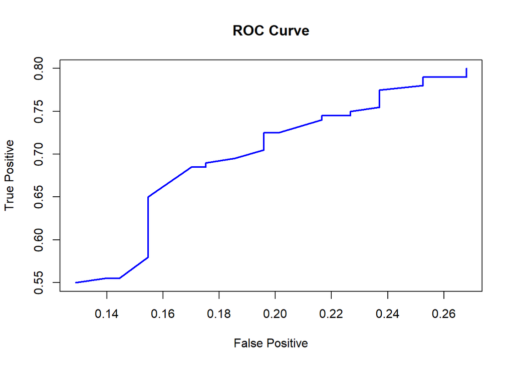

```r
plot.roc(heart.pred,heart$diag, main = "ROC Curve", col = "blue")
```

Question 21 Which predictor variables can you include in principal components analysis?

```r
str(heart)
```

```
## 'data.frame':    394 obs. of  8 variables:
##  $ age    : int  40 49 37 48 39 45 54 37 48 37 ...
##  $ sex    : Factor w/ 2 levels "0","1": 2 1 2 1 2 1 2 2 1 1 ...
##  $ cp     : Factor w/ 4 levels "1","2","3","4": 2 3 2 4 3 2 2 4 2 3 ...
##  $ restbps: int  140 160 130 138 120 130 110 140 120 130 ...
##  $ chol   : int  289 180 283 214 339 237 208 207 284 211 ...
##  $ fbs    : int  0 0 0 0 0 0 0 0 0 0 ...
##  $ restecg: Factor w/ 3 levels "0","1","2": 1 1 2 1 1 1 1 1 1 1 ...
##  $ diag   : int  0 1 0 1 0 0 0 1 0 0 ...
```

Question 22 Perform PCA on the variables in question 21 using the correlation matrix. Rounded to a whole number, what percent of the variance is explained by the first two PCs? (Do not include the % symbol in your answer)

```r
heart.pca <- princomp(heart[,c("age", "restbps", "chol","diag")], cor = T)

# Cumulative variance
cum.heart <- cumplot(heart.pca)
cum.heart$cumvar
```

```
##    Component Proportion
## 1:    Comp.1  0.3704553
## 2:    Comp.2  0.6454397
## 3:    Comp.3  0.8494196
## 4:    Comp.4  1.0000000
```

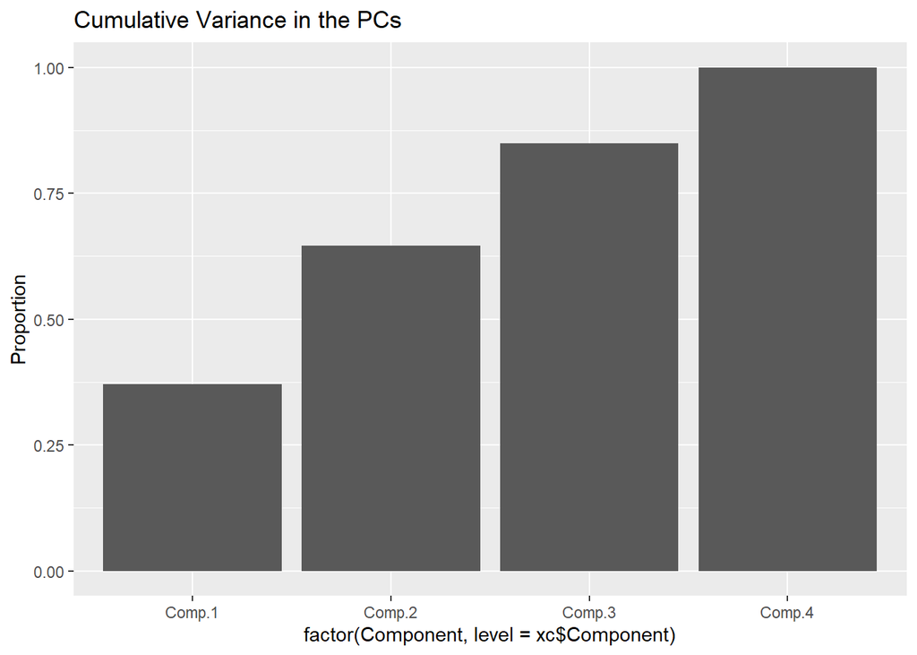

```r
cum.heart$plot
```

Question 23 Build a PC regression model using the number of PCs needed to explain 75% of the variability. Using the deviance test, is the model significant at the 5% level?

```r
heart.glm75 <- pc.glm(heart.pca, 75, heart$diag)
heart.pc.null <- pc.null(heart.pca, 75, heart$diag)
```

```r
# deviance test
anova(heart.pc.null, heart.glm75,test="Chi")
```

```
## Analysis of Deviance Table
##
## Model 1: r ~ 1
## Model 2: r ~ Comp.1 + Comp.2 + Comp.3
##   Resid. Df Resid. Dev Df Deviance  Pr(>Chi)
## 1       393     546.11
## 2       390       8.58  3   537.53 < 2.2e-16 ***
## ---
## Signif. codes:  0 '***' 0.001 '**' 0.01 '*' 0.05 '.' 0.1 ' ' 1
```

Question 24 Rounded to one decimal place, the AIC of the PC regression model is: 16.6

Rounded to one decimal place, the AIC of the stepwise model from question 17: 397.3

```r
AIC(heart.glm75)
```

```
## [1] 16.5754
```

```r
AIC(heart.step)
```

```
## [1] 397.2813
```

Question 25 Using a probability threshold of 0.5, compute a confusion matrix for the PC regression model. There are:

```r
heart.pred2 <- predict(heart.glm75)
```

```r
# confusion matrix
score.table(heart.pred2, heart$diag, .5)
```

```
## Actual vs. Predicted
```

```
##       Pred
## Actual FALSE TRUE
##      0   193    1
##      1     1  199
```

# Part 3 Time Series

```r
sunspot <- read.table("sunspot.csv", sep = ",", header = T)
sunspot.ts<-ts(sunspot$sunspotarea)
```

Question 26 Plot the periodogram of the sunspot time series without the “spans” argument. Rounded to one decimal, the period of the peak with maximum frequency is _________ years.

```r
pg.sunspot<- spec.pgram(sunspot.ts,demean=T,log='no')
```

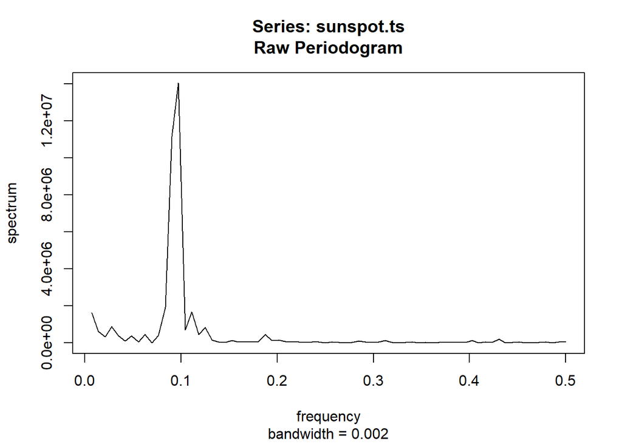

```r
# Find the peak, max.omega
max.omega<-pg.sunspot$freq[which(pg.sunspot$spec==max(pg.sunspot$spec))]

# Where is the peak?
max.omega
```

```
## [1] 0.09722222
```

```r
# What is the period?
1/max.omega
```

```
## [1] 10.28571
```

Repeat with the argument “spans=12”. Rounded to one decimal, the period of the peak with maximum frequency is ________ years.

```r
pg.sunspot2<- spec.pgram(sunspot.ts,spans=12,demean=T,log='no')
```

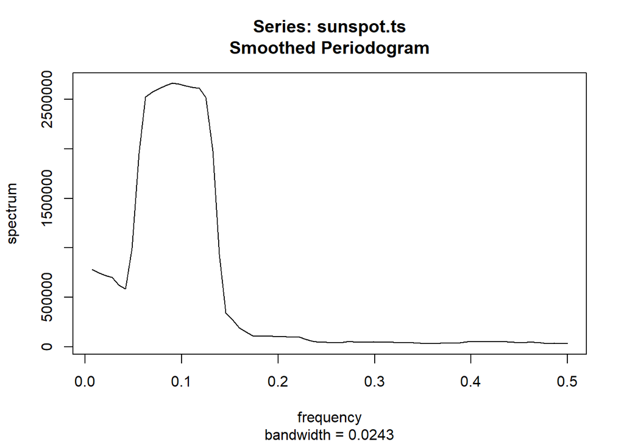

```r
# Find the peak, max.omega
max.omega2<-pg.sunspot2$freq[which(pg.sunspot2$spec==max(pg.sunspot2$spec))]

# Where is the peak?
max.omega2
```

```
## [1] 0.09027778
```

```r
# What is the period?
1/max.omega2
```

```
## [1] 11.07692
```

Question 27 Build a model of the trend and seasonality of the sunspot time series. To model seasonality, use trigonometric functions assuming a period equal to the average of your two answers in Question 26. Controlling for seasonality, is there a statistically significant trend in the sunspot time series?

```r
period <- (max.omega + max.omega2) / 2
t <- c(seq(1,dim(sunspot)[1]))

sunspot.trend.seasonal <- lm(sunspot.ts ~ t + sin(2*pi*t/period) + cos(2*pi*t/period))
summary(sunspot.trend.seasonal)
```

```
##
## Call:
## lm(formula = sunspot.ts ~ t + sin(2 * pi * t/period) + cos(2 *
##     pi * t/period))
##
## Residuals:
##     Min      1Q  Median      3Q     Max
## -1093.8  -547.2  -184.0   439.0  2181.5
##
## Coefficients:
##                        Estimate Std. Error t value Pr(>|t|)
## (Intercept)             546.396    123.427   4.427 1.94e-05 ***
## t                         4.137      1.508   2.743   0.0069 **
## sin(2 * pi * t/period)  -17.397     86.803  -0.200   0.8414
## cos(2 * pi * t/period)   15.432     86.812   0.178   0.8592
## ---
## Signif. codes:  0 '***' 0.001 '**' 0.01 '*' 0.05 '.' 0.1 ' ' 1
##
## Residual standard error: 728.8 on 137 degrees of freedom
## Multiple R-squared:  0.05259,    Adjusted R-squared:  0.03185
## F-statistic: 2.535 on 3 and 137 DF,  p-value: 0.05943
```

Question 28 Plot the acf of the residuals of your Question 27 model. Which of the following is true?

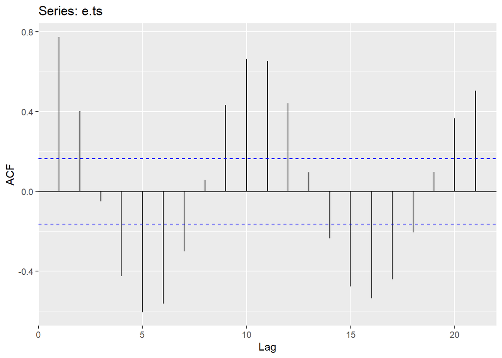

```r
e.ts <- ts(sunspot.trend.seasonal$residuals)
ggAcf(e.ts)
```

Question 29 Plot the pacf of the residuals of your Question 27 model. Which of the following is true?

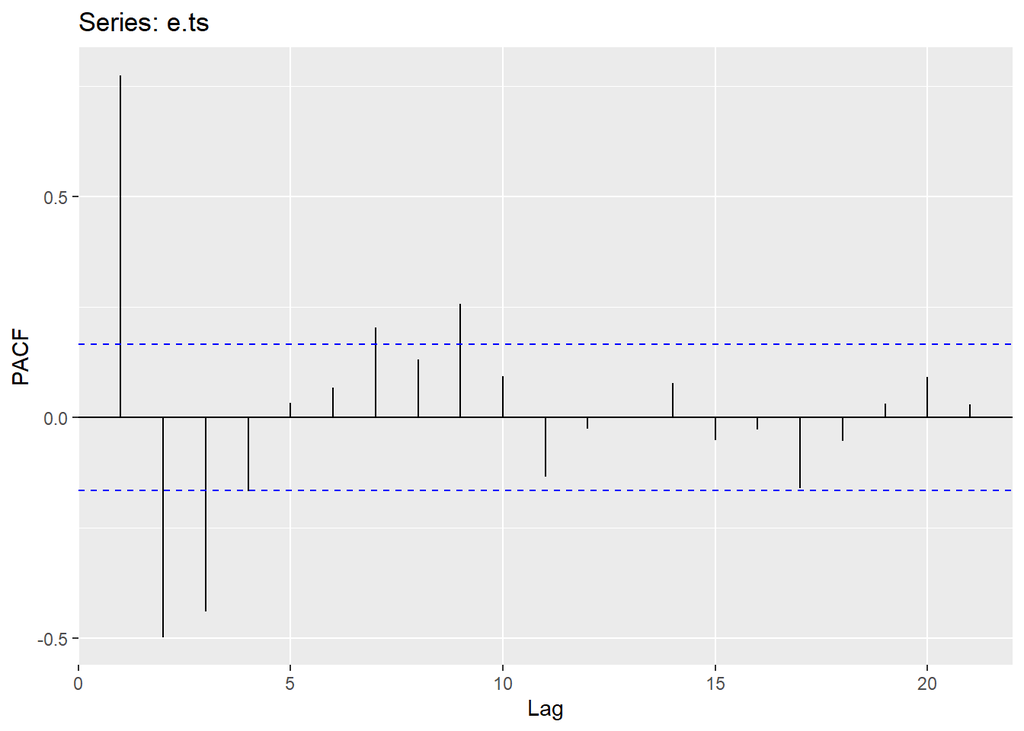

```r
ggPacf(e.ts)
```

Question 30 Build an auto.arima model to the residuals of your Question 27 model using the argument “approximation=FALSE”. What is the order of the model?

```r
sunspot.auto <- auto.arima(e.ts,approximation=FALSE)
summary(sunspot.auto)
```

```
## Series: e.ts
## ARIMA(4,0,2) with zero mean
##
## Coefficients:
##          ar1      ar2     ar3     ar4      ma1     ma2
##       2.3392  -1.9445  0.3981  0.1638  -1.5873  0.7774
## s.e.  0.1086   0.2678  0.2623  0.1034   0.0783  0.0817
##
## sigma^2 = 107287:  log likelihood = -1015.38
## AIC=2044.76   AICc=2045.6   BIC=2065.4
##
## Training set error measures:
##                     ME     RMSE      MAE       MPE     MAPE      MASE
## Training set -9.601363 320.5025 248.2368 -33.16233 222.0104 0.7196164
##                     ACF1
## Training set 0.008497759
```

Question 31 Plot the time series diagnostics of the residuals of your ARIMA model in Question 30. Which of the following is true?

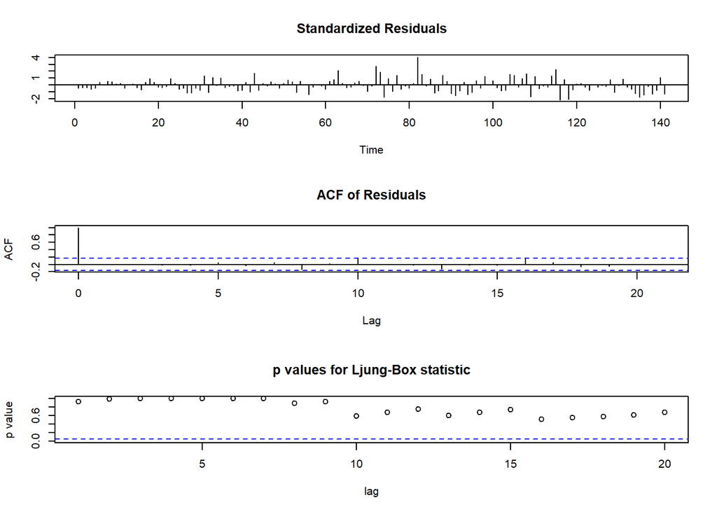

```r
tsdiag(sunspot.auto,gof.lag=20)
```